# Algorithmic Agency

Dennis Tenen

November 21, 2013

# Part I: Posing the question

# Can machines think?

Whimsical Conversation (Joseph Weintraub, 1991 Turing Test Competition):

*Judge 6*:. Hello earth person! *Terminal 5*: Hello there judge, are you ready to have some fun? How ya doin, judge? Hello—how's the weather up there today? *Judge 6*: Dark clouds with occasional burst of sunshine (or rather camera flashes). *Terminal 5*: The trouble with the rat race is that even if you win you’re still a rat. Whimsy can be flimsy, right? How important is that to you? *Judge 6*: I can't say I understand the question . . . but the whimsy of a poet is one thing and the whimsy of most of us is another. *Terminal 5*: How do you know you can't say you understand the question . . . but the whimsy of a poet is one thing and the whimsy of most of us is another. *Judge 6*: Are you repeating me just for laughs? *Terminal 5*: I’m sorry, I do sometimes repeat myself . . . perhaps it's because i can't find my electronic organizer!

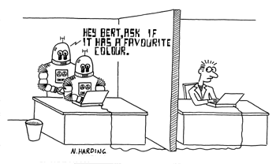

# Functionalism vs. intentionalism (structuralism)

**If it looks, walks, quacks, like a duck--it's a duck.**

Alan Turing (1950):

**It is a duck on the inside and has the right intentions.**

John Searle (1980):

> "*Only a machine could think, and only very special kinds of machines, namely brains and machines with internal causal powers equivalent to those of brains.*"<sup>2</sup>

# Systems solution

Extended cognition, distributed cognition, Integrated information theory, *panpsychism*.

Guilio Tononi (2008):

> "*The quantity of consciousness corresponds to the amount of integrated information generated by a complex of elements.*"<sup>3</sup>

Kristof Koch (2013):

> "*To be conscious, then, you need to be a single, integrated entity with a large repertoire of highly differentiated states.*"<sup>4</sup>

Edwin Hutchins (1995):

> "*This paper presents a theoretical framework that takes a socio-technical system rather than an individual mind as its primary unit of analysis [...] This system-level cognitive view directs our attention beyond the cognitive properties of individuals to the properties of external representations and to the interactions between internal and external representations.*"<sup>5</sup>

# Part II: Case Studies

# 1. Who is landing the plane?

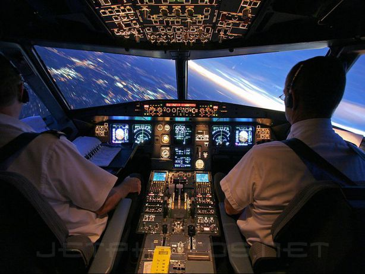

Two types of extension: literal and metaphoric.

# 2. Searle's Chinese room

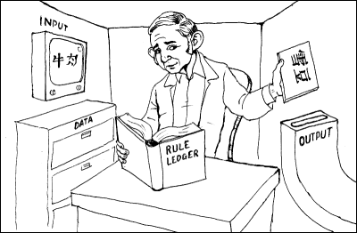

Where are the "smarts"? Which elements of the system incidental?

# 3. The Turing test

Alan Turing, "Computing Machinery and Intelligence" (1950):

*Interrogator*: In the first line of your sonnet which reads “Shall I compare thee to a summer's day” would not “a spring day” do as well or better? *Witness*: It would not scan. *Interrogator*: How about “a winter's day.” That would scan all right. *Witness*: Yes, but nobody wants to be compared to a winter's day. *Interrogator*: Would you say Mr. Pickwick reminded you of Christmas? *Witness*: In a way. *Interrogator*: Yet Christmas is a winter's day, and I do not think Mr. Pickwick would mind the comparison. *Witness*: I don't think you’re serious. By a winter's day one means a typical winter's day, rather than a special one like Christmas.

[figure not shown]

[figure not shown]

[figure not shown]

# Part III: Tentative Conclusions

# Deep genealogy

Plato, *The Republic*, 380 BC:  
> "*What about the city that is most like a single person? For example, when one of us hurts his finger, the entire organism that binds body and soul together into a single system under the ruling part within it is aware of this, and the whole feels the pain together with he part that suffers. That's what we say that the man has a pain in his finger. And the same can be said about any part of man, with regard either to the pain it suffers or to the pleasure it experiences when it finds relief [...] the city with the best government is most like such a person.*"

Ibn Rushd (Averroës), 1190 CE:

> "*Al-Ghazzali has said that a man who makes any of the [secondary] causes to be co-existent with God is like a man who makes the pen share in who makes the pen share the work of a scribe in writing; that is, he says that the pen is a scribe and the man is a scribe too. He means that that "writing" is a word which may be applied to both, but in reality they have no resemblance in anything but word.*"<sup>6</sup>

[On why there is no creator, but God, "and all the causes which He has created, cannot be called creators, except speaking figuratively.]

# Reformulation

Do machines have agency of any kind?

Can systems make decisions?

Are corporations persons?

Can a machine compose music?

Is rote knowledge, knowledge?

Who is landing the plane?

Who is responsible when robots attack?

# Residue

- Algorithms are strange and beautiful things.
- The agency / culpability of complex systems.
- Texts, technologies, communities.

# Meta

Slides produced in Markdown + Pandoc + Slidy

The presentation can be viewed at github.com/denten/talks/tree/master/algorithmic-agency

Follow me on Twitter *@dennistenen*

Email me at *dt2406@columbia.edu*

[^1]: Turing, A. M. “Computing Machinery and Intelligence.*” *Mind* 59, no. 236 (October 1, 1950): 433–460.
[^2]: Searle, John R. “Minds, Brains, and Programs.” *Behavioral and Brain Sciences* 3, no. 03 (1980): 417–424.
[^3]: Tononi, Giulio. “Consciousness as Integrated Information: A Provisional Manifesto.” *The Biological Bulletin* 215, no. 3 (December 1, 2008): 216–242.
[^4]: Koch, Christof. “A ‘Complex’ Theory of Consciousness: Scientific American.” Accessed November 21, 2013.
[^5]: Hutchins, Edwin. “How a Cockpit Remembers Its Speeds.” *Cognitive Science* 19, no. 3 (1995): 265–288.
[^6]: Averroës, and George Fadlo Hourani. Averroës: On the Harmony of Religion and Philosophy. London: Printed for the trustees of the “E.J.W. Gibb Memorial” and published by Luzac, 1961.